# The Simple-to-Complex Principle

Ryan Miller

## The Simple-to-Complex Principle

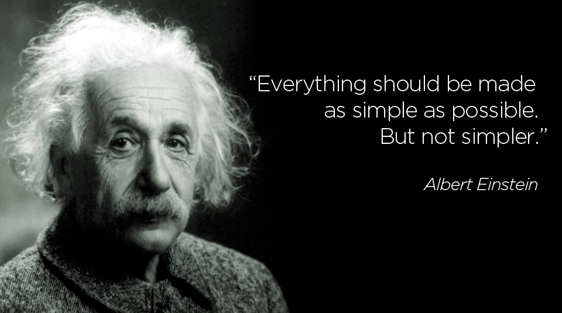

Albert Einstein - Theoretical Physicist (1879 - 1955)

## The Simple-to-Complex Principle

[figure not shown]

E.F. Schumacher - Statistician and Economist (1911 - 1977)

## The Simple-to-Complex Principle

- Data can be intimidating. As an analyst, there’s a nearly infinite number of choices you can make.
  - Some analyses are too simple, they don’t accurately answer your research question or present misleading information.
  - Other analyses are too complex, they make it difficult (or impossible) for you to communicate your findings.

## Example #1

- These data come from a US university as part of the school’s ongoing attempt to analyze salary differences between male and female faculty to evaluate possible discrimination.
  - The simplest possible analysis compares summarized salaries for each sex
  - Question: Using the table below, is there evidence of discrimination?

| sex | median | mean | SE |
| --- | --- | --- | --- |
| Female | 103750 | 101002 | 4156 |
| Male | 108043 | 115090 | 1609 |

## Example #1

- There is a fairly substantive salary difference, but our simple analysis failed to account for possible **confounding variables**
  - What if male professors at this university are more experienced? What if male professors are in higher paying disciplines?
- Recall that confounding variables can be accounted for by using **stratification** - this complicates the analysis, but the added complexity is necessary to get an accurate answer
  - Question: After stratifying by rank, is there evidence of discrimination?

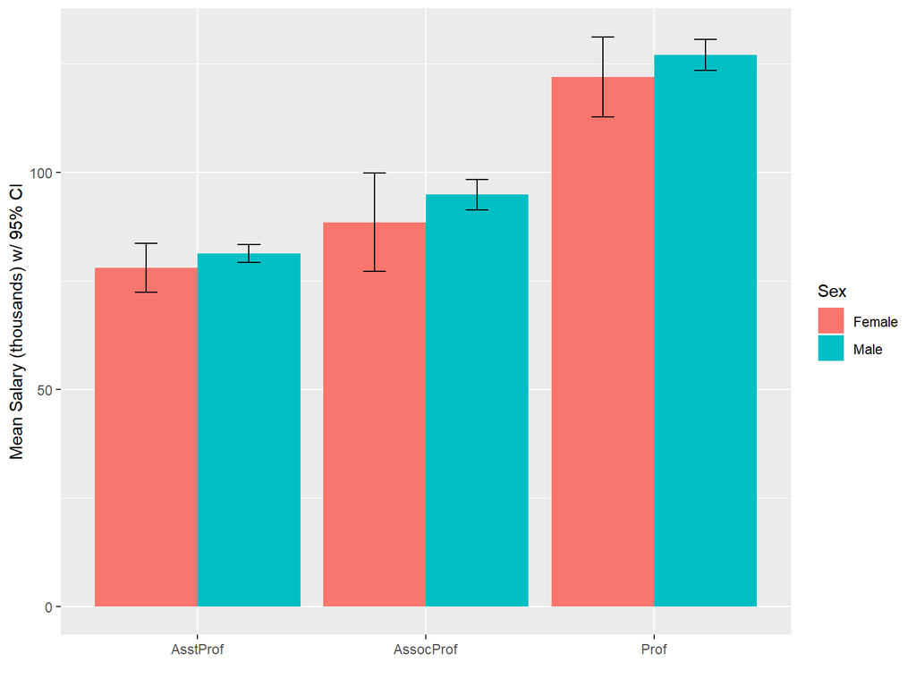

## Example #1 - Conclusions

- In the professor salary example, stratification was necessary to account for confounding variables
  - A careful analysis of these data would consider more potential confounding variables than just “Rank”, but this simple example illustrates why it is important to think about multivariate relationships within your data

## Example #2

- In the previous example, some additional complexity was needed, presenting the un-stratified data was misleading
  - In other situations, adding complexity can detract from the analysis
- This example looks at the relationship between a home’s size and its sale price for homes sold in Iowa City between 2005 and 2007
  - We expect larger sized homes have higher sale prices
  - But does this relationship depend on the size of the lot that the home was built upon?
  - Question: Based upon the graphs below, do we need to consider lot size when describing the relationship between a home’s size (living area) and it’s sale price?

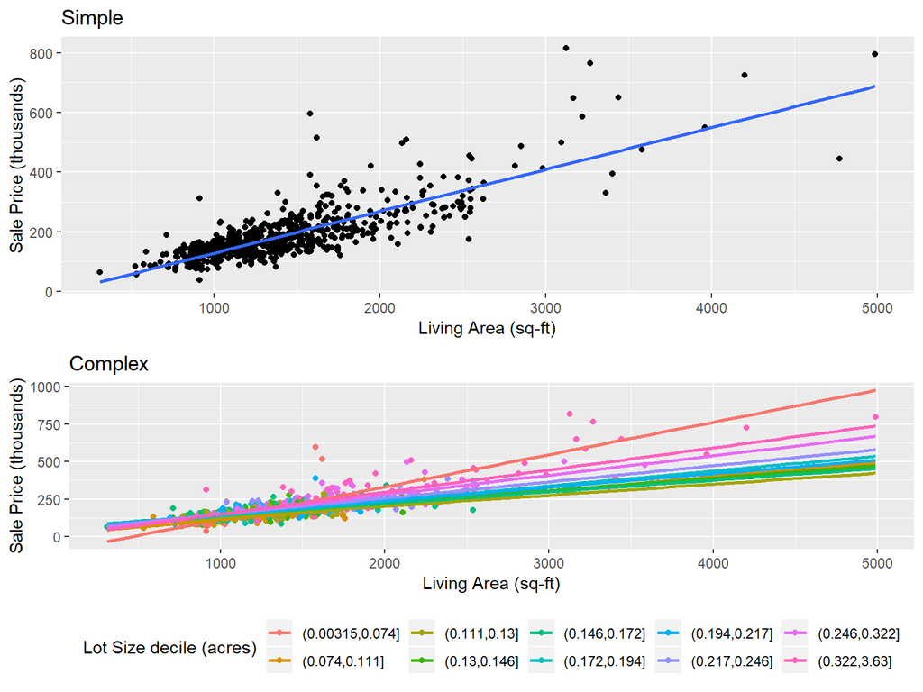

## Another Example

- From the previous plot, it appears the relationship between home size (living area) and sale prices is fairly consistent regardless of the lot size
- We could further support this statement by looking at the **adjusted** and **unadjusted** regression coefficients

| Unadjusted Effect | Adjusted Effect |
| --- | --- |
| 0.14 (0.133, 0.147) | 0.126 (0.119, 0.134) |

- While the overlap in the 95% CIs is relatively small, we could also argue that there is little practical difference between the adjusted and unadjusted effects
  - A 500 sq-ft increase in living area is expected to increase a home’s value by $70,000 (unadjusted) or $63,200 (adjusted for lot size)
  - Both of these tell a similar story, meaning the added complexity introduced by adjusting for lot size could be considered unnecessary
  - A counter argument is that isn’t too difficult to explain the adjusted coefficient, even though it’s based upon a model with more complexity

## The Takeaway

- The analysis approaches you use shouldn’t be so simple that they suggests inaccurate conclusions
- But they also shouldn’t be so complex that they introduce unnecessary artifacts or render you unable to effectively communicate your results

> “Everything should be made as simple as possible, but not simpler.” - Albert Einstein

## `tidyr` lead-in

Today’s lab will provide the foundation for formatting data in a way so that it can plotted.

1. Record the information depicted in this graph as a tabular dataset
2. How do you think these data were formatted in `R` to be able to construct this graph?

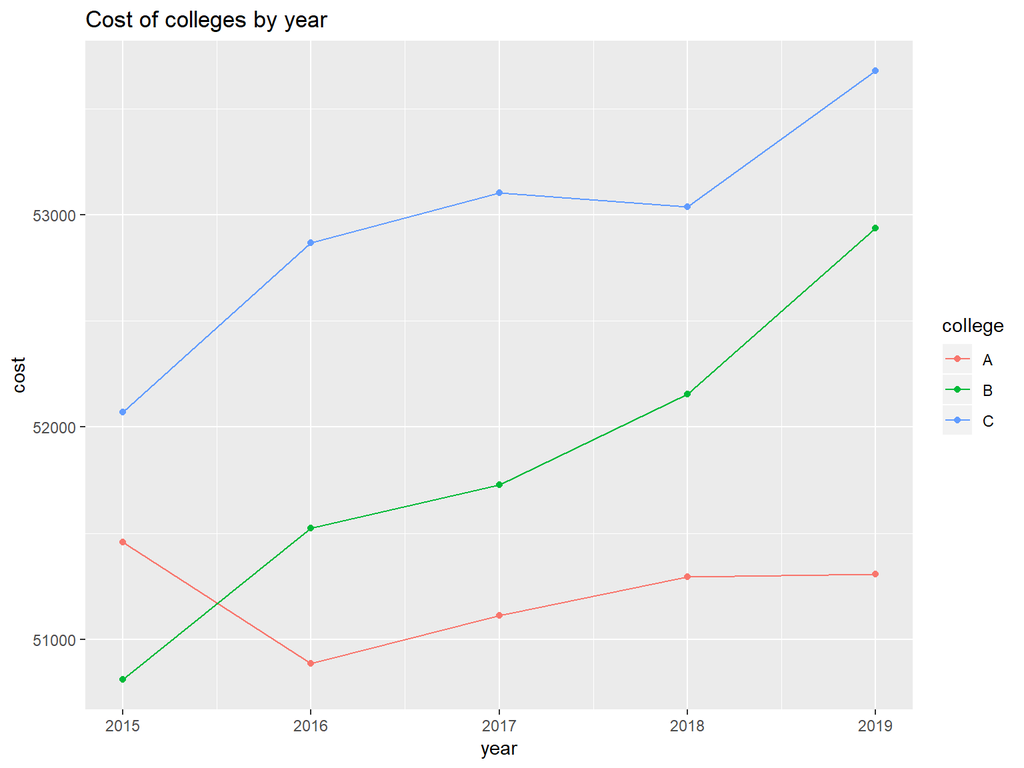